# Bootstrap Vignette

```r
source("~/Documents/STA380project/R/bootstrap.R")
```

This vignette demonstrates three functions for sleep duration statistics with the bootstrap resampling method:

- compute_sleep_duration(): Compute sleep duration as the difference between wake time and bedtime.
- bootstrap_mean(): Generate bootstrap estimates of the sample mean using resampling with replacement.
- bootstrap_ci() Compute a percentile bootstrap confidence interval.

# Compute sleep duration

In this example, bedtimes and wake times are recorded on a 24-hour clock. If wake time is smaller than bedtime, the function assumes sleep crosses midnight and adjusts accordingly.

```r
set.seed(1)
n <- 10^4
uptime  <- c( 7.0, 6.0, 9.0, 7.5, 6.0)
bedtime <- c(22.0, 22.5, 1.0, 0.0, 0.5)
sleep_hours <- compute_sleep_duration(bedtime, uptime)
sleep_hours
```

```
## [1] 9.0 7.5 8.0 7.5 5.5
```

```r
summary(sleep_hours)
```

```
##    Min. 1st Qu.  Median    Mean 3rd Qu.    Max.
##     5.5     7.5     7.5     7.5     8.0     9.0
```

# Bootstrap mean of sleep duration

we apply the bootstrap to estimate the mean sleep duration of the sampling distribution.

```r
set.seed(1)
B <- 10^4
boot_means_sleep <- bootstrap_mean(sleep_hours, B = B)
head(boot_means_sleep)
```

```
## [1] 7.7 8.1 7.0 6.9 7.4 7.9
```

```r
length(boot_means_sleep)
```

```
## [1] 10000
```

## Histogram

Visualizing the bootstrap of mean sleep duration

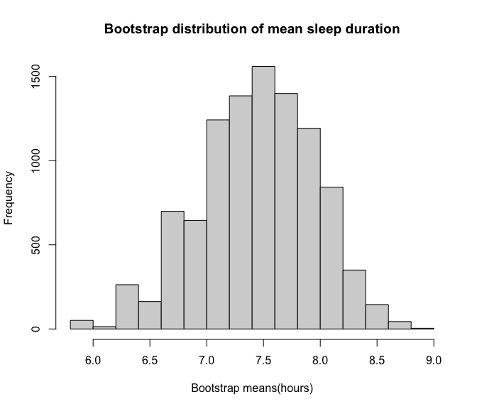

```r
hist(boot_means_sleep,
     main = "Bootstrap distribution of mean sleep duration",
     xlab = "Bootstrap means(hours)")
```

## Bootstrap summary statistics (Mean)

```r
original_mean <- mean(sleep_hours)

boot_mean <- mean(boot_means_sleep)
boot_se <- sd(boot_means_sleep)
boot_bias <- boot_mean - original_mean
boot_median <- median(boot_means_sleep)
boot_ci <- quantile(boot_means_sleep, c(0.025, 0.975))

mean_summary <- data.frame(
  Metric = c("Original estimate",
             "Bootstrap mean",
             "Bootstrap SE",
             "Bias",
             "Bootstrap median",
             "95% CI (2.5%)",
             "95% CI (97.5%)"),
  Value = c(original_mean,
            boot_mean,
            boot_se,
            boot_bias,
            boot_median,
            boot_ci[1],
            boot_ci[2])
)

mean_summary
```

```
##              Metric     Value
## 1 Original estimate  7.500000
## 2    Bootstrap mean  7.494520
## 3      Bootstrap SE  0.507326
## 4              Bias -0.005480
## 5  Bootstrap median  7.500000
## 6     95% CI (2.5%)  6.400000
## 7    95% CI (97.5%)  8.400000
```

# Bootstrap Median Estimator

We apply the bootstrap to estimate the median sleep duration of the sampling distribution.

```r
set.seed(1)
B <- 10^4
boot_median_sleep <- bootstrap_median(sleep_hours, B = B)
head(boot_median_sleep)
```

```
## [1] 7.5 8.0 7.5 5.5 7.5 7.5
```

```r
length(boot_median_sleep)
```

```
## [1] 10000
```

## histogram

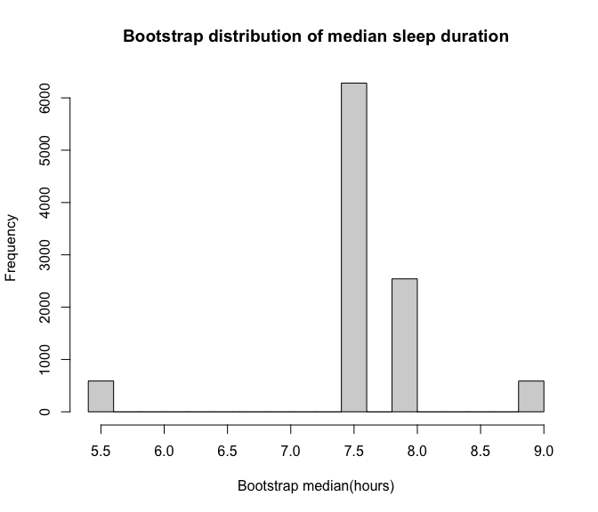

```r
hist(boot_median_sleep,
     main = "Bootstrap distribution of median sleep duration",
     xlab = "Bootstrap median(hours)")
```

## Bootstrap summary statistics (Median)

```r
original_median <- median(sleep_hours)

boot_mean_med <- mean(boot_median_sleep)
boot_se_med <- sd(boot_median_sleep)
boot_bias_med <- boot_mean_med - original_median
boot_median_med <- median(boot_median_sleep)
boot_ci_med <- quantile(boot_median_sleep, c(0.025, 0.975))

median_summary <- data.frame(
  Metric = c("Original estimate",
             "Bootstrap mean",
             "Bootstrap SE",
             "Bias",
             "Bootstrap median",
             "95% CI (2.5%)",
             "95% CI (97.5%)"),
  Value = c(original_median,
            boot_mean_med,
            boot_se_med,
            boot_bias_med,
            boot_median_med,
            boot_ci_med[1],
            boot_ci_med[2])
)

median_summary
```

```
##              Metric     Value
## 1 Original estimate 7.5000000
## 2    Bootstrap mean 7.5974500
## 3      Bootstrap SE 0.6495927
## 4              Bias 0.0974500
## 5  Bootstrap median 7.5000000
## 6     95% CI (2.5%) 5.5000000
## 7    95% CI (97.5%) 9.0000000
```

# Percentile bootstrap confidence interval

Compute the lower and upper bound of the 95% percentile bootstrap confidence interval.

```r
cl95_sleep <- bootstrap_ci(boot_means_sleep, conf_level = 0.95)
cl95_sleep
```

```
##  2.5% 97.5%
##   6.4   8.4
```

# Assumption checks

In this bootstrap, we do not need to check normality, but it needs the following assumptions:

- Independence: Observations of sleep duration should be independent.
- Representative: Observations should come from the target population.
- Sample size: Sample size n should be big enough to make bootstrap_ci() stable.
- Outliers: Outliers will effect the bootstrap_mean() and bootstrap_ci().

# Checking sample size

```r
sleep_sample <- sleep_hours[!is.na(sleep_hours)]
n <- length(sleep_sample)
if (n < 10) {
  warning("Sample size n is too small!")
}
```

# Checking outliers

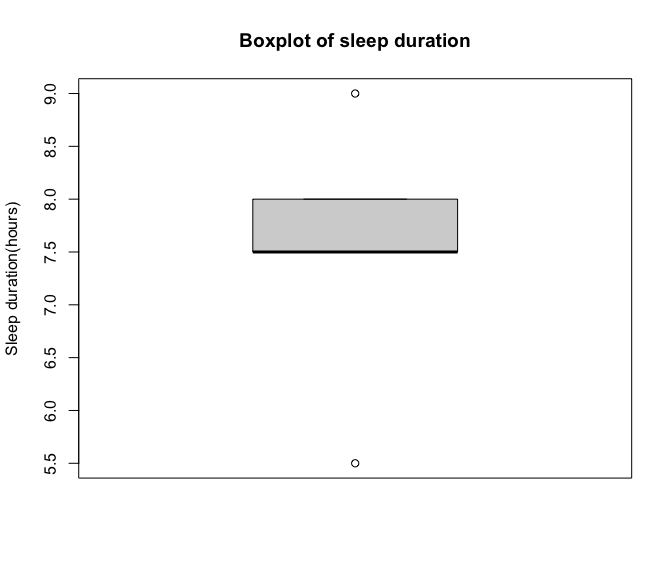

```r
sleep_sample <- sleep_hours[!is.na(sleep_hours)]
Q1 <- quantile(sleep_sample, 0.25)
Q3 <- quantile(sleep_sample, 0.75)
IQR <- IQR(sleep_sample)
lower_tail <- Q1 - 1.5 * IQR
upper_tail <- Q3 + 1.5 * IQR

boxplot(sleep_sample,
        main = "Boxplot of sleep duration",
        ylab = "Sleep duration(hours)")
```

# Bibliography

Marqueze, Elaine Cristina, Suleima Vasconcelos, Johanna Garefelt, Debra J. Skene, Claudia Roberta Moreno, and Arne Lowden. 2015. “Natural Light Exposure, Sleep and Depression Among Day Workers and Shiftworkers at Arctic and Equatorial Latitudes.” *PLOS ONE* 10 (4): e0122078. https://doi.org/10.1371/journal.pone.0122078.

# AI usage

1. https://chatgpt.com/share/699e88bf-3d1c-8003-ac39-9186bb8e1d24